# Communicate Data Findings Project

This project has two parts that demonstrate the importance and value of data visualization techniques in the data analysis process. In the first part, you will use Python visualization libraries to systematically explore a selected dataset, starting from plots of single variables and building up to plots of multiple variables. In the second part, you will produce a short presentation that illustrates interesting properties, trends, and relationships that you discovered in your selected dataset. The primary method of conveying your findings will be through transforming your exploratory visualizations from the first part into polished, explanatory visualizations.

# Ford GoBike System

# What is/are the main feature(s) of interest in your dataset?

This dataset have many trips , which related to the start and end of the trip and if the trip is on weekdays or weekend bike user data is also available from age, gender, and type of users subscriber or customer

# What features in the dataset do you think will help support your investigation into your feature(s) of interest?

- start_station_id - user_type - member_birth_year - bike_share_for_all_trip - age_member - duration_minites - start_of_weekday

# Univariate Exploration

# How many users for the year?

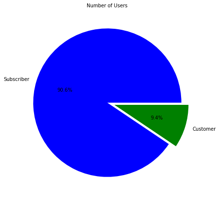

Most of the bike users are subscribers 90% ,but customer 9.4%

# Distribution of Trip Durations

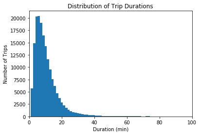

that most customer use the bike for 1 to 20 and 30 minutes

# Daily bike Usage

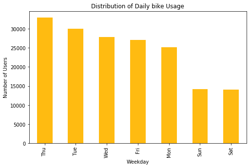

# hour bike Usage

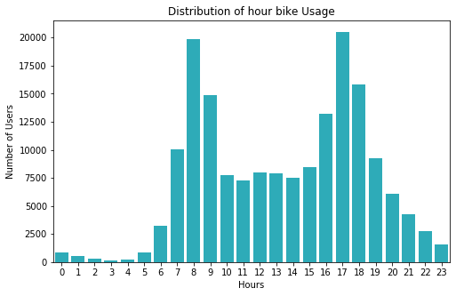

The most use of bike the morning between 8-9 am , and afternoon between 17-18 pm

# What is the Age Distribution?

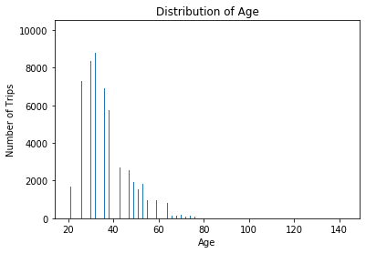

the most number of trips 20-40